# TAD VD: Primer Informe

Roberto Sánchez

2023-10-08

## Visualización Interactiva del “Árbol de la Vida” Bacteriano en R.

### Introducción

Los árboles son un tipo de estructura de datos común compuesta por un set de nodos interconectados. Formalmente, se consideran grafos acíclicos conectados.

Los árboles filogenéticos permiten visualizar las relaciones evolutivas entre varios organismos en base a las diferencias en la secuencia de ADN de uno de sus genes. En ellos, cada nodo interno representa un teórico ancestro común a partir del cual divergieron otros dos nodos, las hojas representan los organismos a partir de los cuales se construyó el árbol. El eje x representa el número de mutaciones que ha sufrido un gen a lo largo del tiempo.

La base de datos [GTDB](https://gtdb.ecogenomic.org/) recoge más de 400.000 genomas de Bacterias y Arqueas (Procariotas), las cuales representan bien la totalidad de procariotas. Usando un set grande de genes de cada organismo, ha construido un árbol “filogenómico” que muestra las relaciones evolutivas entre ellas. Usando este árbol, GTDB les asigna con precisión una taxonomía con 7 niveles: dominio, filo, clase, orden, familia, género y especie.

Actualmente, la base de datos no ofrece una visualización de este árbol. Representar un árbol de este tamaño puede ser computacionalmente costoso y resulta difícil de interpretar. Una posible solución para esto sería emplear visualizaciones interactivas.

Este trabajo trata de crear visualizaciones interactivas en R de este árbol, que incluyan anotaciones de taxonomía. Además, el árbol vendría enfrentado a otros datos genómicos de interés proporcionados por GTDB. Estas son:

- el tamaño del genoma.
- el porcentaje del genoma que está formado por genes.
- el porcentaje de bases del ADN que son G o C.

Para ello emplearía la suite de paquetes asociados a [ggtree](https://yulab-smu.top/treedata-book/index.html), y ggiraph. Si esto resulta exitoso, podría implementar una sencilla aplicación web [Shiny](https://shiny.posit.co/) que permita navegar por el árbol clicando en un taxón para visualizar sus taxones descendientes.

### Paquetes empleados.

- **tidyverse**
- **tidytree**, para la manipulación de árboles filogenéticos
- **ggtree**, para la visualización de árboles filogenéticos
- **ggiraph**, para transformar ggplots en interacivos. Originalmente en la descripción proponía plotly, pero estoy obteniendo mejores resultados con ggiraph

```r
library(tidyverse)
library(tidytree)
library(ggtree)
library(ggiraph)
library(cowplot)
```

Descargar datos

```r
if (!file.exists("data")) {
  dir.create("data")
}

gtdb_root <- "https://data.gtdb.ecogenomic.org/releases/release214/214.1/"
tree_url <- paste0(gtdb_root, "bac120_r214.tree")
metadata_url <- paste0(gtdb_root, "bac120_metadata_r214.tsv.gz")

source("scripts/download_data.R")

download_and_unzip(tree_url)
```

```
## File already exists: data/bac120_r214.tree
## File is not a ZIP archive: bac120_r214.tree
## Process complete.
```

```r
download_and_unzip(metadata_url)
```

```
## File already exists: data/bac120_metadata_r214.tsv.gz
## Unzipping file: bac120_metadata_r214.tsv.gz
```

```
## Process complete.
```

## Exploración de los metadatos

```r
source("scripts/read_data.R")

metadata_file <- file.path("data", "bac120_metadata_r214.tsv")
metadata <- read_metadata(metadata_file)
metadata
```

```
## # A tibble: 394,932 × 5
##    gtdb_genome_represen…¹ coding_density gc_percentage genome_size gtdb_taxonomy
##    <chr>                           <dbl>         <dbl>       <dbl> <chr>
##  1 RS_GCF_001457635.1               86.2          39.5     2118732 d__Bacteria;…
##  2 RS_GCF_001457635.1               86.3          39.6     2146574 d__Bacteria;…
##  3 RS_GCF_000269965.1               86.3          59.4     2564809 d__Bacteria;…
##  4 RS_GCF_003026365.1               85.0          39.5     4856945 d__Bacteria;…
##  5 RS_GCF_001591705.1               86.8          35.7     2427048 d__Bacteria;…
##  6 RS_GCF_003697165.2               87.4          50.5     5731065 d__Bacteria;…
##  7 RS_GCF_003697165.2               85.5          50.5     4913352 d__Bacteria;…
##  8 RS_GCF_001027105.1               84.4          32.8     2912364 d__Bacteria;…
##  9 RS_GCF_000008545.1               95.0          46.2     1869610 d__Bacteria;…
## 10 RS_GCF_006757745.1               86.1          41.4     3349161 d__Bacteria;…
## # ℹ 394,922 more rows
## # ℹ abbreviated name: ¹gtdb_genome_representative
```

### Histograma 2D tamaño vs %GC

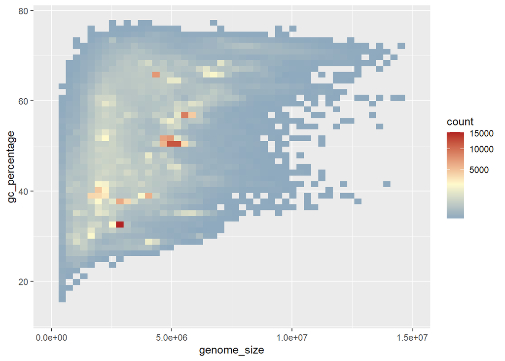

```r
metadata |>
  ggplot(aes(x = genome_size, y = gc_percentage)) +
  geom_bin2d(bins = 50) +
  scale_fill_gradient2(
    low = "steelblue",
    mid = "lemonchiffon",
    high = "firebrick",
    midpoint = sqrt(2500),
    trans = "sqrt") +
  xlim(0, 1.5e7)
```

### Tamaño del genoma vs Porcentaje de GC de los 7 órdenes más comunes

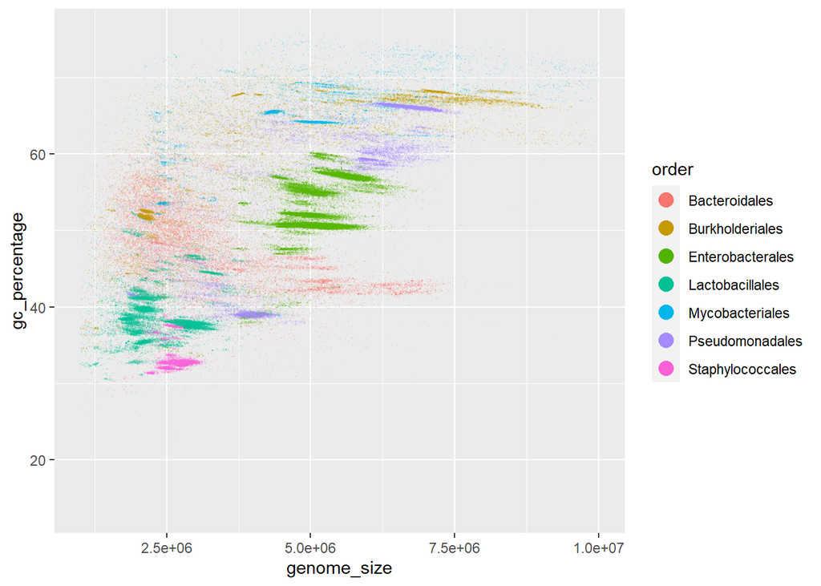

```r
metadata |>
  mutate(
    order = str_match(gtdb_taxonomy, "o__(.+?);")[,2],
    order = fct_lump_n(order, 7)
  ) |>
  filter(order != "Other") |>
  ggplot(aes(x = genome_size, y = gc_percentage, color = order)) +
  geom_point(alpha = 0.1, size = 0.1) +
  xlim(1e6, 1e7) +
  # Use solid points on the legend
  guides(color = guide_legend(override.aes = list(size = 4, alpha = 1)))
```

Al nivel “orden”, tanto el tamaño como el %GC varían bastante. Sin embargo el %GC parece distribuirse en “bandas”, que quizás pertenzcan a taxones más pequeños.

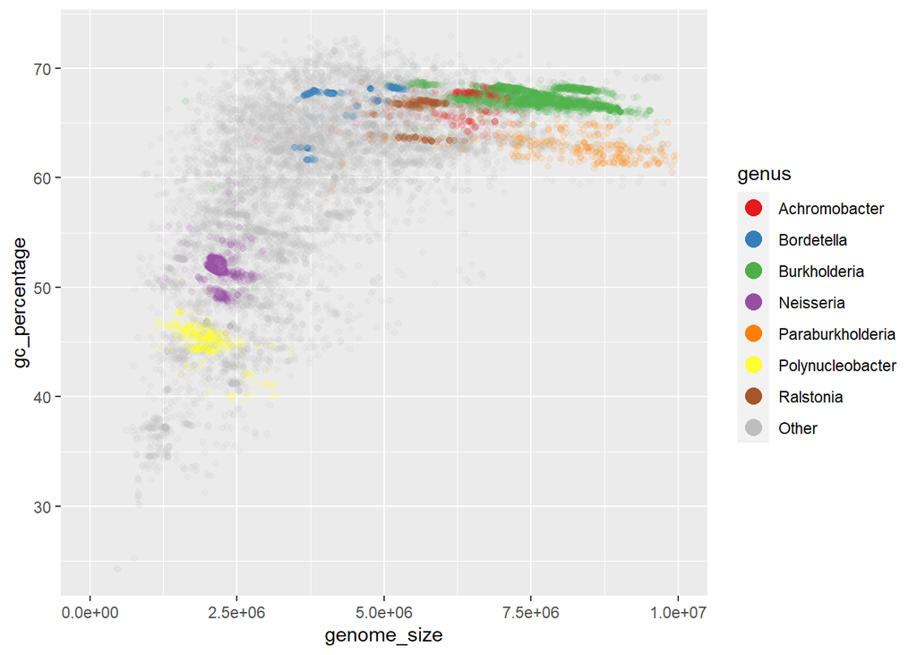

```r
metadata |>
  filter(str_detect(gtdb_taxonomy, "o__Burkholderiales")) |>
  mutate(
    genus = str_match(gtdb_taxonomy, "g__(.+?);")[,2],
    genus = fct_lump_n(genus, 7)
  ) |>
  ggplot(aes(x = genome_size, y = gc_percentage, color = genus)) +
  geom_point(alpha = 0.1) +
  guides(color = guide_legend(override.aes = list(size = 4, alpha = 1))) +
  scale_color_manual(values = c(RColorBrewer::brewer.pal(7, "Set1"), "gray")) +
  xlim(0, 1e7)
```

El %GC parece ser una medida característa de cada género, al menos en este orden. El tamaño, sin embargo varía mucho dentro de algunos géneros, mientras que en otros (ej, *Neisseria*) es menos variable. Veamos este género.

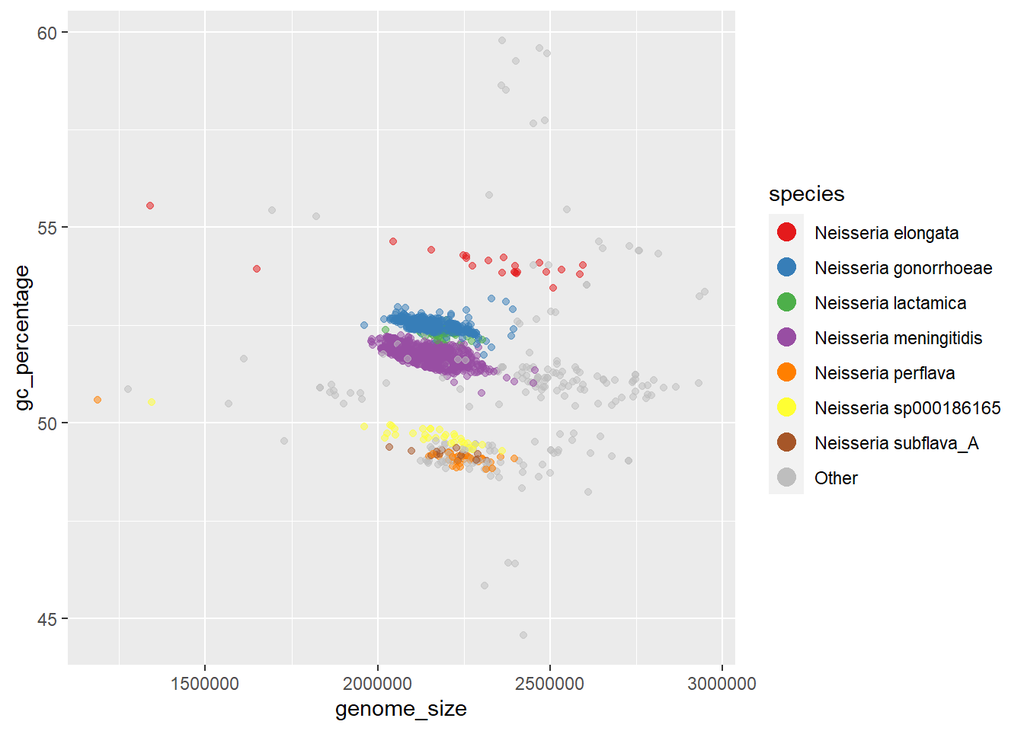

```r
metadata |>
  filter(str_detect(gtdb_taxonomy, "g__Neisseria")) |>
  mutate(
    species = str_match(gtdb_taxonomy, "s__(.+?)$")[,2],
    species = fct_lump_n(species, 7)
  ) |>
  ggplot(aes(x = genome_size, y = gc_percentage, color = species)) +
  geom_point(alpha = 0.5) +
  guides(color = guide_legend(override.aes = list(size = 4, alpha = 1))) +
  scale_color_manual(values = c(RColorBrewer::brewer.pal(7, "Set1"), "gray"))
```

Como vemos, estas medidas varían de forma muy dispar entre unos taxones y otros. En algunos casos, a un cierto nivel taxonomico los taxones se ven separados, mientras que en otros no. Además, con colores solo podemos distinguir un pequeño subconjunto de los taxones, y no podemos ver las relaciones entre ellos.

```r
tax_levels <- c("domain",
                "phylum",
                "class",
                "order",
                "family",
                "genus",
                "species")

tree_file <- file.path("data", "bac120_r214.tree")
gtdb_tree <- read_and_format_tree(tree_file, metadata)
```

### Árbol del orden *Burkholderiales* mostrando su %GC

Una forma más sencilla de comparar taxones entre sí es mostrar un árbol, agrupar las hojas de este árbol en taxones, y mostrar una de las variables para cada una de las agrupaciones, por ejemplo, en un boxplot.

```r
source("scripts/wrangle_tree.R")
source("scripts/plot_tree.R")

tree_burkhold <- subset_tree_to_taxon(gtdb_tree, "order", "Burkholderiales")  |>
  ggtree() |>
  # Todas las familias ocuparán el mismo espacio en el eje y
  scale_tree_to_level("family") |>
  # Añadimos anotaciones interactivas a los taxones
  annotate_taxon_nodes("family", metadata) |>
  # En vez de representar el árbol completo, mostramos triángulos agrupando cada familia
  collapse_tree_to_level("family") |>
  # Anotamos las puntas o hojas
  add_tips() |>
  add_bootstraps()

source("scripts/plot_boxes.R")
tree_burkhold$coordinates$expand <- FALSE

boxplot_burkhold <- plot_stat_boxplot(
  tree_burkhold,
  level = "family",
  stat = "gc_percentage"
  )

grid <- plot_tree_and_boxplots(tree_burkhold, boxplot_burkhold)
girafe(ggobj = grid, height_svg = 10, options = opts_sizing(rescale = FALSE))
```

[interactive chart not shown]

Al pasar el ratón por el nodo de un taxón, nos dirá su nombre y su número de genomas

Veamos otro ejemplo no relacionado.

### Filo *Myxococcota*, agrupado por género mostrando su tamaño

Aquí seleccionamos otro subconjunto (Myxococcota) a un nivel más alto (filo), agruparemos a un nivel más bajo (género), y mostraremos otra variable (tamaño).

```r
tree_myxo <- subset_tree_to_taxon(gtdb_tree, "phylum", "Myxococcota")  |>
  ggtree() |>
  scale_tree_to_level("genus") |>
  collapse_tree_to_level("genus") |>
  add_tips()

boxplot_myxo <- plot_stat_boxplot(tree_myxo, "genome_size")

grid_myxo <- plot_tree_and_boxplots(tree_myxo, boxplot_myxo)
girafe(ggobj = grid_myxo, height_svg = 20, options = opts_sizing(rescale = FALSE))
```

[interactive chart not shown]

```r
tree_poly <- subset_tree_to_taxon(gtdb_tree, "order", "Polyangiales") |>
  ggtree() |>
  scale_tree_to_level("family") |>
  annotate_taxon_nodes("family") |>
  collapse_tree_to_level("family") |>
  add_tips()

boxplot_poly <- plot_stat_boxplot(
  tree_poly,
  level = "family",
  stat = "genome_size",
  show_datapoints = TRUE # Aquí representamos todos los puntos
  )

grid_poly <- plot_tree_and_boxplots(tree_poly, boxplot_poly)
girafe(ggobj = grid_poly, height_svg = 3, options = opts_sizing(rescale = FALSE))
```

[interactive chart not shown]

Con este subconjunto de datos más manejable se pueden representar cómodamente todos los puntos de datos. Al pasar el ratón se puede saber su taxonomía completa.

Estos plot interactivos pueden ser mejorados de las siguientes maneras:

- Los triángulos se podrían colorear por un nivel más alto de taxonomía.
- El color o el tamaño de estos puntos, podría indicar otra variable.
- Al pasar el ratón por un boxplot, podrían salir los quartiles

### Perspectivas:

Una aplicación web Shiny que permita a un usuario seleccionar su taxón de interés, seleccionar la variable que quiere representar, seleccionar las anotaciones que le parezcan relevantes y, lo más importante, ir a un subset del árbol clicando en uno de sus nodos, podría ser útil para no-programadores que quieran explorar este set de datos.